# 7 Design of Experiments

- Show All Code
- Hide All Code
- View Source

## 7.1 Context for Computer Experiments

In classical physical experiments, Design of Experiments (DOE) strategies minimize the variance of the estimated regression coefficients in the presence of random measurement noise [1]. Common designs such as the *Central Composite Design* (CCD) and the *Box-Behnken design* were developed with this goal in mind.

Computer experiments present a fundamentally different setting [2]:

- Outputs are **deterministic** — the same inputs always produce the same output. Replication provides no statistical benefit.
- The primary concern is **space-filling** — ensuring sample points cover the design space well so that the response surface captures the underlying function accurately throughout the region.
- **Cost** is per-evaluation, not per-experiment-run, so economizing on total sample count is important.

Altus (2002) investigated three point placement schemes for BLISS-RS:

1. **Hypersphere point placement** — points dispersed uniformly on the surface of an $n$-dimensional unit hypersphere and projected inward.
2. **Extreme (random) point placement** — uniform random samples in the coded design space, serving as a baseline comparison.
3. **D-optimal design** — points that maximize $\det([X]^T[X])$, chosen via a coordinate exchange algorithm.

The thesis concluded that D-optimal placement provided the best balance of accuracy and economy for BLISS-RS, and that was the scheme adopted for the supersonic business jet results.

## 7.2 Hypersphere Point Placement

The hypersphere scheme attempts to distribute points uniformly across the design space by placing them on the surface of a unit hypersphere in $n$ dimensions, then projecting inward. The anti-bunching property of the sphere surface — the angular repulsion between points — promotes dispersion.

A point is generated by sampling from a standard Gaussian distribution in $n$ dimensions and normalising to unit length:

$$\mathbf{u} \sim \mathcal{N}(0, I_n), \qquad
\hat{\mathbf{u}} = \frac{\mathbf{u}}{\|\mathbf{u}\|}
\tag{7.1}$$

The full algorithm is detailed in Appendix A. An important characteristic is that the number of points is limited only by the minimum required for the RS model — unlike CCD or Box-Behnken designs, whose point counts grow as specific functions of $n$.

**Important2002 Paper Errata — Fig. 19 caption**

NASA/CR-2002-211652, Fig. 19 caption contains a typographical error: “Hypershpere” (missing ‘e’). Not a mathematical error, but noted for completeness. See Appendix C for the full errata list.

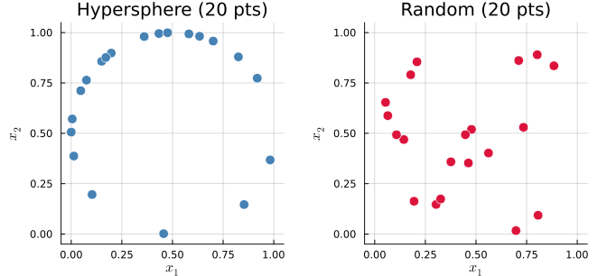

```julia
rng = MersenneTwister(42)

hs_pts = hypersphere_points(2, 20; seed=42)
rn_pts = random_points(2, 20; seed=42)

p1 = scatter(hs_pts[:,1], hs_pts[:,2],
             xlabel=L"x_1", ylabel=L"x_2",
             title="Hypersphere (20 pts)", markersize=6,
             color=:steelblue, markerstrokecolor=:white, legend=false,
             xlim=(-0.05, 1.05), ylim=(-0.05, 1.05), aspect_ratio=1,
             grid=true, gridalpha=0.3)

p2 = scatter(rn_pts[:,1], rn_pts[:,2],
             xlabel=L"x_1", ylabel=L"x_2",
             title="Random (20 pts)", markersize=6,
             color=:crimson, markerstrokecolor=:white, legend=false,
             xlim=(-0.05, 1.05), ylim=(-0.05, 1.05), aspect_ratio=1,
             grid=true, gridalpha=0.3)

plot(p1, p2, size=(700, 320))
```

## 7.3 D-Optimal Point Placement

The **D-optimal design** criterion seeks to maximize the determinant of the information matrix $[X]^T[X]$:

$$\text{Maximize} \quad \det\!\left([X(\xi)]^T[X(\xi)]\right)
\tag{7.2}$$

This is equivalent to minimizing the volume of the confidence ellipsoid for the regression coefficients $\hat{\boldsymbol{\beta}}$. A design with a high $\det([X]^T[X])$ estimates the coefficients with minimum overall uncertainty.

D-optimal designs are generated algorithmically. The **coordinate exchange** algorithm (Cook & Nachtsheim, 1980) works as follows:

1. Initialize with a random set of candidate points $\xi_1, \ldots, \xi_m$.
2. For each point $\xi_i$, for each coordinate $j$:
   - Try replacing $\xi_{i,j}$ with a new candidate value.
   - Accept if $\det([X]^T[X])$ increases.
3. Repeat until no improvement is found.

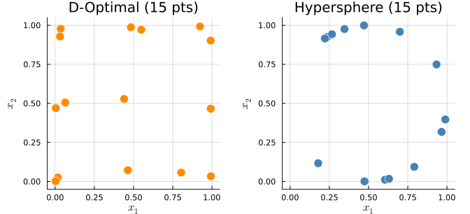

Figure 7.2: D-optimal design (left) vs. hypersphere placement (right) for n=2 variables, 15 points. The D-optimal design emphasises the edges and corners of the design space, which is where second-order model accuracy is most critical.

```julia
dopt_pts = d_optimal_points(2, 15; seed=42)
hs15_pts = hypersphere_points(2, 15; seed=42)

p1 = scatter(dopt_pts[:,1], dopt_pts[:,2],
             xlabel=L"x_1", ylabel=L"x_2",
             title="D-Optimal (15 pts)", markersize=7,
             color=:darkorange, markerstrokecolor=:white, legend=false,
             xlim=(-0.05, 1.05), ylim=(-0.05, 1.05), aspect_ratio=1,
             grid=true, gridalpha=0.3)

p2 = scatter(hs15_pts[:,1], hs15_pts[:,2],
             xlabel=L"x_1", ylabel=L"x_2",
             title="Hypersphere (15 pts)", markersize=7,
             color=:steelblue, markerstrokecolor=:white, legend=false,
             xlim=(-0.05, 1.05), ylim=(-0.05, 1.05), aspect_ratio=1,
             grid=true, gridalpha=0.3)

plot(p1, p2, size=(700, 320))
```

### 7.3.1 Key Features of D-Optimal Designs

One particularly valuable feature of the D-optimal algorithm is that the user can specify the *exact* number of points desired (regardless of the classic design formulas). This is critical in BLISS-RS because:

- The minimum $N_S$ from Equation 6.9 can be augmented by any number of additional points to improve fit robustness, without the rigidity of CCD or Box-Behnken counts.
- In each BLISS iteration, if a particular sample point fails to converge in its local BB optimization, a replacement random point can be substituted without invalidating the design.

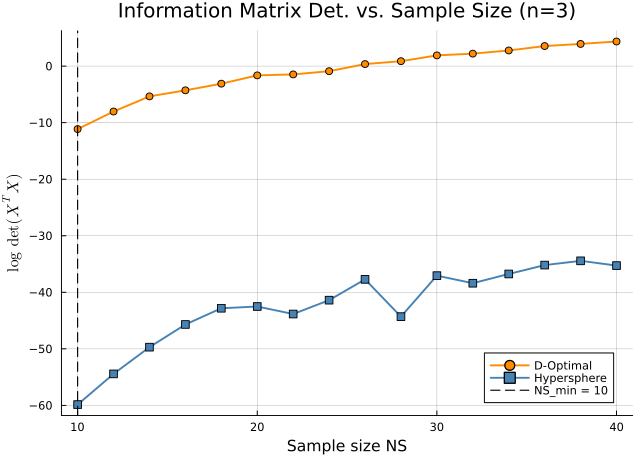

Figure 7.3: Log-determinant of the information matrix X’X as a function of sample size, comparing D-optimal and hypersphere placement for n=3 variables. D-optimal consistently achieves higher det(X’X), indicating better-conditioned regression.

```julia
n_vars = 3
ns_min = min_rs_points(n_vars)
n_pts_range = ns_min:2:(ns_min + 30)

log_det_dopt = Float64[]
log_det_hs   = Float64[]

for n_pts in n_pts_range
    pts_d = d_optimal_points(n_vars, n_pts; seed=42)
    pts_h = hypersphere_points(n_vars, n_pts; seed=42)
    X_d = rs_design_matrix(pts_d);  push!(log_det_dopt, log(max(abs(det(X_d'*X_d)), 1e-300)))
    X_h = rs_design_matrix(pts_h);  push!(log_det_hs,   log(max(abs(det(X_h'*X_h)), 1e-300)))
end

plot(collect(n_pts_range), log_det_dopt, lw=2, color=:darkorange,
     label="D-Optimal",
     xlabel="Sample size NS", ylabel=L"\log\,\det(X^TX)",
     title="Information Matrix Det. vs. Sample Size (n=3)",
     legend=:bottomright, grid=true, gridalpha=0.3, marker=:circle, markersize=4)
plot!(collect(n_pts_range), log_det_hs, lw=2, color=:steelblue,
     label="Hypersphere", marker=:square, markersize=4)
vline!([ns_min], color=:black, linestyle=:dash, lw=1.2, label="NS_min = $ns_min")
```

## 7.4 Latin Hypercube Sampling

Altus (2002) did not evaluate **Latin Hypercube Sampling** (LHS), yet it has become the standard first-choice DOE for deterministic computer experiments in the years since [2,3].

### 7.4.1 Motivation

The D-optimal+random hybrid used in the original BLISS-RS has a structural weakness: when a D-optimal design point fails to converge in its local BB optimization, it is replaced by a random fallback point. This contaminates the $\det([X]^T[X])$ that the D-optimal criterion maximises, and the resulting design’s statistical properties are never quantified. In the supersonic business jet application, the structures BB ($N_X = 11$, $N_S = 78$) and aerodynamics BB ($N_X = 14$, $N_S = 120$) both required fallback points due to structural constraint violations at certain design points.

LHS eliminates this problem by construction.

### 7.4.2 Algorithm

A Latin Hypercube design with $m$ points in $n$ variables divides the range $[0,1]$ of each variable into $m$ equal-width strata and places exactly one point per stratum per variable. The positions within each stratum are randomised independently:

$$x_{i,j} = \frac{\pi_j(i) - u_{i,j}}{m}, \quad u_{i,j} \sim \mathcal{U}(0,1)
\tag{7.3}$$

where $\pi_j$ is a random permutation of $\{1, \ldots, m\}$ for dimension $j$. This guarantees that the projection of the design onto any single axis is perfectly uniform — no stratum is empty, none is crowded. No convergence criterion, no fallback points, no post-hoc D-efficiency check required.

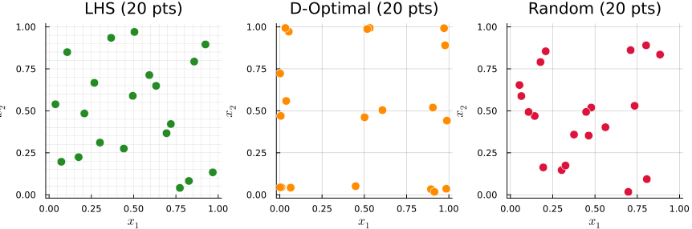

Figure 7.4: LHS, D-optimal, and random placement for n=2, m=20. LHS distributes points uniformly along each axis (perfect marginal uniformity) while D-optimal concentrates on the boundary. For the curved BB responses in BLISS-RS, LHS provides better interior coverage.

```julia
lhs_pts  = lhs_points(2, 20; seed=42)
dopt_pts = d_optimal_points(2, 20; seed=42)
rand_pts = random_points(2, 20; seed=42)

function grid_lines_plot!(p, m)
    for k in 0:m
        v = k / m
        hline!(p, [v], color=:gray, lw=0.3, alpha=0.4, label="")
        vline!(p, [v], color=:gray, lw=0.3, alpha=0.4, label="")
    end
end

p1 = scatter(lhs_pts[:,1], lhs_pts[:,2],
             title="LHS (20 pts)", xlabel=L"x_1", ylabel=L"x_2",
             markersize=6, color=:forestgreen, markerstrokecolor=:white,
             legend=false, xlim=(-0.02,1.02), ylim=(-0.02,1.02), aspect_ratio=1,
             grid=false)
grid_lines_plot!(p1, 20)

p2 = scatter(dopt_pts[:,1], dopt_pts[:,2],
             title="D-Optimal (20 pts)", xlabel=L"x_1", ylabel=L"x_2",
             markersize=6, color=:darkorange, markerstrokecolor=:white,
             legend=false, xlim=(-0.02,1.02), ylim=(-0.02,1.02), aspect_ratio=1,
             grid=true, gridalpha=0.3)

p3 = scatter(rand_pts[:,1], rand_pts[:,2],
             title="Random (20 pts)", xlabel=L"x_1", ylabel=L"x_2",
             markersize=6, color=:crimson, markerstrokecolor=:white,
             legend=false, xlim=(-0.02,1.02), ylim=(-0.02,1.02), aspect_ratio=1,
             grid=true, gridalpha=0.3)

plot(p1, p2, p3, size=(900, 300), layout=(1,3))
```

The LHS grid lines in Figure 7.4 illustrate the defining property: each row and each column of the $m \times m$ grid contains exactly one point. D-optimal placement concentrates points near the boundary (the region of maximum leverage for coefficient estimation) but leaves the interior sparsely sampled. Random placement can produce both gaps and clusters by chance.

### 7.4.3 Comparative Validation on the Rosenbrock Function

```julia
rosenbrock(x) = sum(100*(x[i+1] - x[i]^2)^2 + (x[i]-1)^2 for i in 1:length(x)-1)

function doe_comparison(n_vars, ns_extra=10, n_trials=30)
    ns = min_rs_points(n_vars) + ns_extra
    rmse_lhs  = Float64[]
    rmse_dopt = Float64[]
    rmse_rand = Float64[]
    for seed in 1:n_trials
        for (pts_fn, vec) in [(s -> lhs_points(n_vars, ns; seed=s),  rmse_lhs),
                               (s -> d_optimal_points(n_vars, ns; seed=s), rmse_dopt),
                               (s -> random_points(n_vars, ns; seed=s), rmse_rand)]
            pts = pts_fn(seed)
            pts_coded = 2 .* pts .- 1.0
            y = [rosenbrock(pts_coded[i,:]) for i in 1:ns]
            push!(vec, loocv_error(pts, y).rmse)
        end
    end
    return mean(rmse_lhs), mean(rmse_dopt), mean(rmse_rand)
end

println("| NX | NS | LHS RMSE | D-Opt RMSE | Random RMSE | LHS vs Random |")
println("|----|-----|----------|------------|-------------|---------------|")
for (nv, extra) in [(2,10), (3,15), (5,25), (8,50)]
    ns = min_rs_points(nv) + extra
    r_lhs, r_dopt, r_rand = doe_comparison(nv, extra)
    improvement = (r_rand - r_lhs) / r_rand * 100
    @printf("| %2d | %3d | %.3f | %.3f | %.3f | %+.1f%% |\n",
            nv, ns, r_lhs, r_dopt, r_rand, improvement)
end
```

```
| NX | NS | LHS RMSE | D-Opt RMSE | Random RMSE | LHS vs Random |
|----|-----|----------|------------|-------------|---------------|
|  2 |  16 | 53.485 | 97.522 | 47.055 | -13.7% |
|  3 |  25 | 74.427 | 114.565 | 69.592 | -6.9% |
|  5 |  46 | 108.308 | 147.337 | 107.417 | -0.8% |
|  8 |  95 | 133.813 | 156.645 | 137.881 | +3.0% |
```

## 7.5 Coded and Natural Variables

DOE algorithms work in a *coded* design space where all variables are normalised to the interval $[-1, 1]$ (or equivalently $[0, 1]$). Physical design variables, by contrast, occupy widely different scales and units (degrees, square feet, unitless ratios). A coordinate mapping connects the two:

$$\xi = \frac{X - X_C}{\Delta X / 2} = \frac{2(X - X_L)}{X_U - X_L} - 1
\tag{7.4}$$

where $X_L$ and $X_U$ are the lower and upper bounds on the physical variable $X$, $X_C = (X_L + X_U)/2$ is the centre, and $\xi \in [-1, 1]$ is the coded variable. Conversely:

$$X = X_L + \frac{\xi + 1}{2}(X_U - X_L)
\tag{7.5}$$

```julia
# Demonstrate the mapping for wing sweep angle (40° to 70°)
x_L, x_H = 40.0, 70.0
coded_vals   = [-1.0, -0.5, 0.0, 0.5, 1.0]
natural_vals = code_to_natural.(coded_vals, x_L, x_H)

println("Wing Sweep Mapping (xL=40°, xH=70°)")
println("ξ (coded)  →  Λ_w (natural, deg)")
for (ξ, x) in zip(coded_vals, natural_vals)
    @printf("  %+5.2f   →  %6.2f°\n", ξ, x)
end
```

```
Wing Sweep Mapping (xL=40°, xH=70°)
ξ (coded)  →  Λ_w (natural, deg)
  -1.00   →   40.00°
  -0.50   →   47.50°
  +0.00   →   55.00°
  +0.50   →   62.50°
  +1.00   →   70.00°
```

In BLISS-RS, the bounds $X_L$ and $X_U$ are *adaptive* — they start as the physical design limits and are reduced each iteration to focus the RS on a smaller, more reliably-approximated region around the current system optimum (Chapter 6).

## 7.6 Space-Filling Diagnostics

Two useful diagnostics for assessing point placement quality are:

**Minimum distance** ($d_{\min}$) — the smallest Euclidean distance between any pair of sample points. A high $d_{\min}$ indicates no two points are excessively close.

**Coverage** — the maximum distance from any point in the design space to its nearest sample point. Low coverage means the design has explored the space thoroughly.

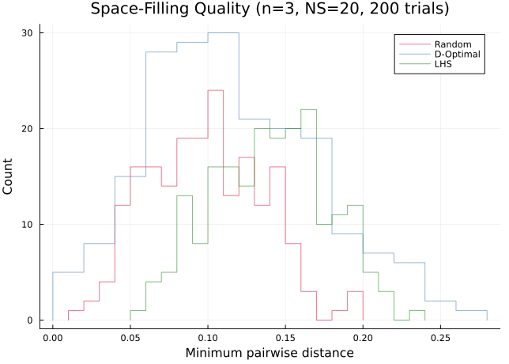

```julia
function min_pairwise_dist(pts::Matrix{Float64})
    m = size(pts, 1)
    d_min = Inf
    for i in 1:m, j in (i+1):m
        d = norm(pts[i,:] - pts[j,:])
        d_min = min(d_min, d)
    end
    return d_min
end

n_trials = 200
d_random  = [min_pairwise_dist(random_points(3, 20; seed=seed)) for seed in 1:n_trials]
d_dopt    = [min_pairwise_dist(d_optimal_points(3, 20; seed=seed, n_iter=300)) for seed in 1:n_trials]
d_lhs     = [min_pairwise_dist(lhs_points(3, 20; seed=seed)) for seed in 1:n_trials]

stephist(d_random, bins=20, label="Random", color=:crimson, alpha=0.6,
         xlabel="Minimum pairwise distance", ylabel="Count",
         title="Space-Filling Quality (n=3, NS=20, 200 trials)")
stephist!(d_dopt, bins=20, label="D-Optimal", color=:steelblue, alpha=0.6)
stephist!(d_lhs, bins=20, label="LHS", color=:forestgreen, alpha=0.6)
```

[1]

Myers, R. H., and Montgomery, D. C., “Response Surface Methodology: Process and Product Optimization Using Designed Experiments,” John Wiley & Sons, New York, 2002.

[2]

Sacks, J., Welch, W. J., Mitchell, T. J., and Wynn, H. P., “Design and Analysis of Computer Experiments,” *Statistical Science*, Vol. 4, No. 4, 1989, pp. 409–423.

[3]

Stein, M., “Large Sample Properties of Simulations Using Latin Hypercube Sampling,” *Technometrics*, Vol. 29, No. 2, 1987, pp. 143–151. https://doi.org/10.1080/00401706.1987.10488205